# Running pyqz

This page is also available as an IPython notebook (*pyqz_demo.ipynb*) located in *pyqz/examples/*.

*Warning 1: the code syntax in v0.7.0 has changed significantly, and so did the function calls. pyqz v0.7.x is therefore NOT backward compatible with older pyqz versions.*

*Warning 2: the examples below will show you how to run the main functions inside pyqz. **But these do not exempt you from getting acquainted with the "Understanding pyqz" section of the documentation !***

### Installing and importing pyqz

Installing pyqz is easy. Download it from Github, unpack it anywhere you like, and make sure that this location is in your Python path. You should then be able to import the package and check its version from within any Python shell:

```python
import pyqz
pyqz.__version__
```

```
'0.7.2'
```

### Basic use 1: accessing MAPPINGS line ratio diagnostic grids

pyqz gives you easy access to the latest MAPPINGS strong line ratio diagnostic diagrams (and associated info on the MAPPINGS version used to generate the grid, etc...). This can for example be useful to create your own line ratio diagnostic plots. You can access the nodes of any line ratio diagram using *pyqz.get_grid()*:

```python
a_grid = pyqz.get_grid('[NII]/[SII]+;[OIII]/[SII]+', sampling=1)
# Uncomment the line below for a look at the structure of a_grid
# a_grid
```

The main parameters of the MAPPINGS simulations can be specified via the following keywords: - `Pk` let's you define the pressure of the simulated HII regions, - `struct` allows you to choose between plane-parallel (`'pp'`) and spherical (`'sph'`) HII regions, and - `kappa` lets you define the value of $\kappa$ (from the so-called $\kappa$-distribution).

**All these values must match an existing set of MAPPINGS simulations inside the *pyqz/reference_data/* folder, or pyqz will issue an error. In other words, pyqz will not be running new MAPPINGS simulations for you.**

So, if one wanted to access the MAPPINGS simulations for plane-parallel HII regions, with Maxwell-Boltzmann electron density distribution, Pk =5.0, one should type:

```python
a_grid = pyqz.get_grid('[NII]/[SII]+;[OIII]/[SII]+', struct = 'pp', Pk = 5, kappa = 'inf')
# Uncomment the line below for a look at the structure of a_grid
# a_grid
```

If you want to simply check how a given line ratio diagnostic diagram looks (and e.g. check whether the MAPPINGS grid is flat, or wrapped) for line ratios of your choice, you can use *pyqz.check_grid()*:

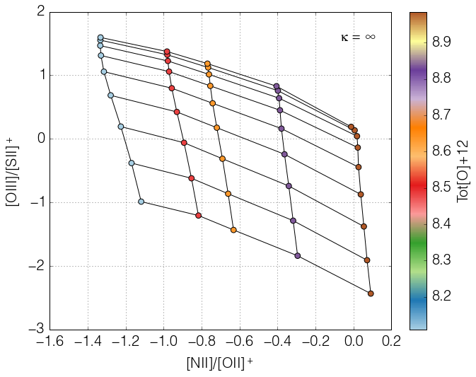

```python
bad_segments = pyqz.check_grid('[NII]/[OII]+;[OIII]/[SII]+', show_plot=True)
```

An important feature of pyqz is the auto-detection of wraps in the diagnostic grids, marked with red segments in the diagram, and returned as an array by the function *pyqz.check_grid()*.

By default, the *default* MAPPINGS grids shipped with pyqz are corse. For various reasons better explained elsewhere (see the MAPPINGS documentation), only a few abundance values have matching stellar tracks **AND** stellar atmospheres. Hence, only a few abundance points can be simulated in a consistent fashion.

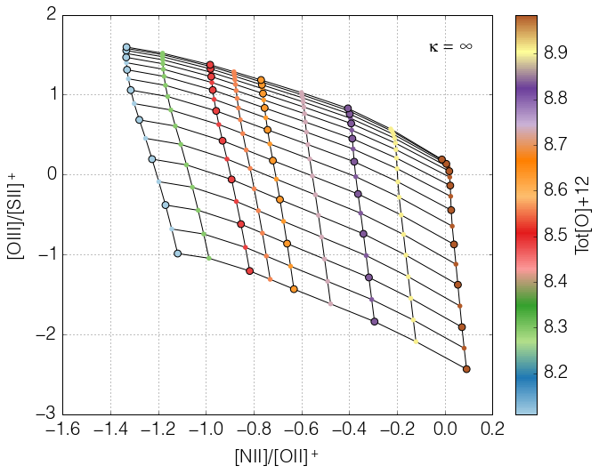

```python
bad_segments = pyqz.check_grid('[NII]/[OII]+;[OIII]/[SII]+',show_plot=True, sampling=2)
```

In the default pyqz diagrams, the **original** MAPPINGS nodes are circled with a black outline, while the **reconstructed** nodes are not. For grids more densely resampled, see the "Advanced use 2" below.

### Basic use 2: deriving `LogQ` and `Tot[O+12]` for a given set of line ratios

At the core of pyqz lies `pyqz.interp_qz()`, which is the basic routine used to interpolate a given line ratio diagnostic grid. The function is being fed by line ratios stored inside numpy arrays, and will only return a value for line ratios landing **on valid and un-wrapped** regions of the grid:

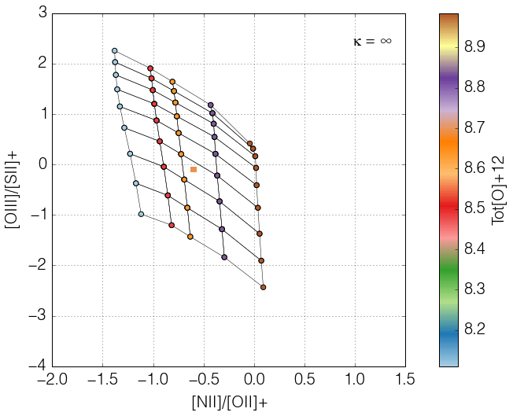

```
array([ 8.697449])
```

```python
z = pyqz.interp_qz('Tot[O]+12',[np.array([-0.6]),np.array([-0.1])],'[NII]/[OII]+;[OIII]/[SII]+',
               sampling=1,struct='pp', show_plot=True)
z
```

Of course, one usually wants to compute both `LogQ` and `Tot[O+12]` or `gas[O+12]` for a large set of strong emission line fluxes, combining the estimates from different line ratio diagnostics diagrams. This is exactly what the function `pyqz.get_global_qz()` allows you to do.

The function is being fed the individual line fluxes and associated errors in the form of numpy arrays and lists. ID tags for each dataset can also be given to the function (these are then used if/when saving the different diagrams to files).

```
--> Processing 1 spectrum ...
```

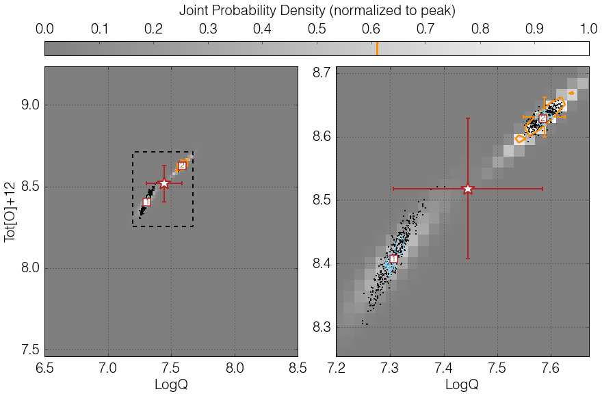

```
All done in 0:00:04.370502
```

```
[array([[  7.30563675e+00,   8.40752058e+00,   7.58464098e+00,
           8.62834536e+00,   7.44513886e+00,   1.39502113e-01,
           8.51793297e+00,   1.10412390e-01,   7.30007583e+00,
           8.69737797e-03,   8.39739984e+00,   1.69106603e-02,
           7.58765550e+00,   1.58882425e-02,   8.62932458e+00,
           1.19835520e-02,   7.58775759e+00,   3.86829996e-02,
           8.63037803e+00,   3.11968890e-02,   9.24000000e+02,
           0.00000000e+00]]),
 ['[NII]/[SII]+;[OIII]/[SII]+|LogQ',
  '[NII]/[SII]+;[OIII]/[SII]+|Tot[O]+12',
  '[NII]/[OII]+;[OIII]/[OII]+|LogQ',
  '[NII]/[OII]+;[OIII]/[OII]+|Tot[O]+12',
  '<LogQ>',
  'std(LogQ)',
  '<Tot[O]+12>',
  'std(Tot[O]+12)',
  '[NII]/[SII]+;[OIII]/[SII]+|LogQ{KDE}',
  'err([NII]/[SII]+;[OIII]/[SII]+|LogQ{KDE})',
  '[NII]/[SII]+;[OIII]/[SII]+|Tot[O]+12{KDE}',
  'err([NII]/[SII]+;[OIII]/[SII]+|Tot[O]+12{KDE})',
  '[NII]/[OII]+;[OIII]/[OII]+|LogQ{KDE}',
  'err([NII]/[OII]+;[OIII]/[OII]+|LogQ{KDE})',
  '[NII]/[OII]+;[OIII]/[OII]+|Tot[O]+12{KDE}',
  'err([NII]/[OII]+;[OIII]/[OII]+|Tot[O]+12{KDE})',
  '<LogQ{KDE}>',
  'err(LogQ{KDE})',
  '<Tot[O]+12{KDE}>',
  'err(Tot[O]+12{KDE})',
  'flag',
  'rs_offgrid']]
```

```python
pyqz.get_global_qz(np.array([[2.88,0.05,1.0,0.01,2.015,0.045,0.036,0.002,2.72,0.12,0.497,0.017,0.500,0.016]]),
                   ['[OII]+','std[OII]+','Hb','stdHb','[OIII]','std[OIII]','[OI]','std[OI]','Ha','stdHa','[NII]','std[NII]','[SII]+','std[SII]+'],
                   ['[NII]/[SII]+;[OIII]/[SII]+','[NII]/[OII]+;[OIII]/[OII]+'],
                   ids = ['NGC_1234'],
                   show_plot='KDE', # set this to True to also see the individual line ratio diagrams
                   save_plot=True,  # set this to 'grids', 'KDE_all', False or 'KDE_flags' (i.e. only the problematic points)
                   plot_loc = './example_plots',
                   struct='pp',
                   sampling=1)
```

By default, all line fluxes errors are assumed to be gaussian, where the input `std` value is the 1 standard deviation. Alternatively, line fluxes can be tagged as upper-limits by setting their errors to -1.

Users less keen on using Python extensively can alternatively feed their data to pyqz via an **appropriately structured** *.csv* file and receive another *.csv* file in return:

```
--> Processing 1 spectrum ...
```

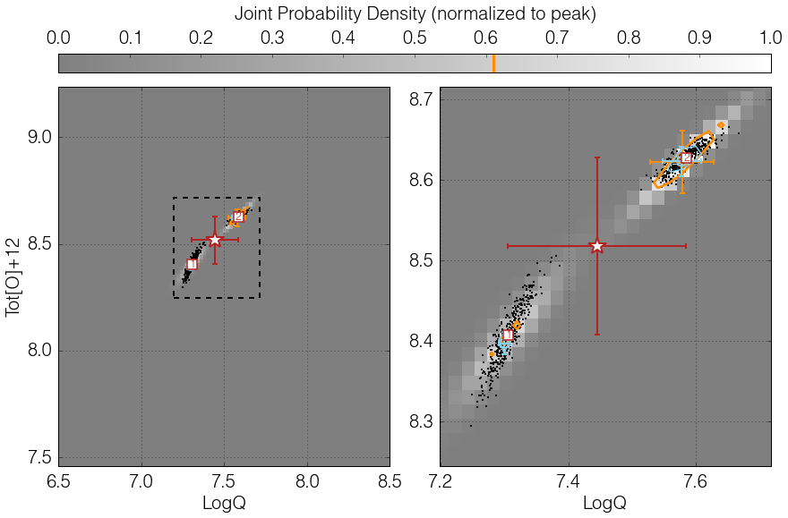

```
All done in 0:00:04.381982
```

```
(array([[  7.30563675e+00,   8.40752058e+00,   7.58464098e+00,
           8.62834536e+00,   7.44513886e+00,   1.39502113e-01,
           8.51793297e+00,   1.10412390e-01,   7.30009089e+00,
           9.35766576e-03,   8.39731789e+00,   1.43132660e-02,
           7.57782295e+00,   3.05980853e-02,   8.62299975e+00,
           1.85412415e-02,   7.57794077e+00,   5.03249097e-02,
           8.62192008e+00,   3.87429978e-02,   9.24000000e+02,
           0.00000000e+00]]),
 ['[NII]/[SII]+;[OIII]/[SII]+|LogQ',
  '[NII]/[SII]+;[OIII]/[SII]+|Tot[O]+12',
  '[NII]/[OII]+;[OIII]/[OII]+|LogQ',
  '[NII]/[OII]+;[OIII]/[OII]+|Tot[O]+12',
  '<LogQ>',
  'std(LogQ)',
  '<Tot[O]+12>',
  'std(Tot[O]+12)',
  '[NII]/[SII]+;[OIII]/[SII]+|LogQ{KDE}',
  'err([NII]/[SII]+;[OIII]/[SII]+|LogQ{KDE})',
  '[NII]/[SII]+;[OIII]/[SII]+|Tot[O]+12{KDE}',
  'err([NII]/[SII]+;[OIII]/[SII]+|Tot[O]+12{KDE})',
  '[NII]/[OII]+;[OIII]/[OII]+|LogQ{KDE}',
  'err([NII]/[OII]+;[OIII]/[OII]+|LogQ{KDE})',
  '[NII]/[OII]+;[OIII]/[OII]+|Tot[O]+12{KDE}',
  'err([NII]/[OII]+;[OIII]/[OII]+|Tot[O]+12{KDE})',
  '<LogQ{KDE}>',
  'err(LogQ{KDE})',
  '<Tot[O]+12{KDE}>',
  'err(Tot[O]+12{KDE})',
  'flag',
  'rs_offgrid'])
```

```python
pyqz.get_global_qz_ff('./example_input.csv',
                      ['[NII]/[SII]+;[OIII]/[SII]+','[NII]/[OII]+;[OIII]/[OII]+'],
                      show_plot='KDE', # set this to True to also see the individual line ratio diagrams
                      save_plot=True,  # set this to 'grids', 'KDE_all', False or 'KDE_flags' (i.e. only the problematic points)
                      plot_loc = './example_plots',
                      struct='pp',
                      sampling=1)
```

The first line of the input file must contain the name of each column, following the pyqz convention. The order itself does not matter, e.g.:

`Id,[OII]+,std[OII]+,Hb,stdHb,[OIII],std[OIII],[OI],std[OI],Ha,stdHa,[NII],std[NII],[SII]+,std[SII]+`

The `Id` (optional) can be used to add a tag (i.e. a string) to each set of line fluxes. This tag will be used in the filenames of the diagrams (if some are saved) and in the output `.csv` file as well.

At this point, it must be stressed that *pyqz.get_global_qz()* only exploit a finite set of diagnostic grids, namely:

```python
pyqz.diagnostics.keys()
```

```
['[NII]/[OII]+;[OIII]/[SII]+',
 '[NII]/Ha;[OIII]/Hb',
 '[NII]/[OII]+;[OIII]/[OII]+',
 '[NII]/[SII]+;[OIII]/Hb',
 '[NII]/[SII]+;[OIII]/[OII]+',
 '[NII]/[SII]+;[NII]/Ha;[OIII]/Hb',
 '[NII]/[OII]+;[OIII]/Hb',
 '[NII]/Ha;[OIII]/[OII]+',
 '[NII]/[SII]+;[OIII]/[SII]+']
```

These specific diagnostic diagrams are chosen to be largely flat, i.e. they are able to cleanly disentangle the influence of `LogQ` and `Tot[O]+12`. One does not need to use all the grids together. For example, if one knows that an [OII] line flux measurement is corrupted, one ought to simply use the diagnostic grids that do not rely on this line to derive the estimates of `LogQ` and `Tot[O]+12`.

Users can easily add new diagnostics to this list (defined inside *pyqz_metadata.py*), but will do so at their own risk.

### Advanced use 1: using custom MAPPINGS grids

While pyqz ships with a default set of HII region simulations from MAPPINGS, some (all!) users might be interested in using pyqz with their own specific sets of MAPPINGS simulations. pyqz was designed to be compatible with the grids generated from the awk script provided alongside MAPPINGS.

**If one uses the awk script to create new MAPPINGS grids**, the resulting `.csv` file must be laced inside *pyqz/reference_data*. The filename must match what the function *pyqz.get_MVphotogrid_fn()* expects for your given set of parameters:

```python
pyqz.get_MVphotogrid_fn(Pk=6.7,calibs='GCZO', kappa =10, struct='pp')
```

```
'/Users/fvogt/Tools/Python/fpav_pylib/pyqz/pyqz_dev/reference_data/grid_QZ_pp_GCZO_Pk67_k10.csv'
```

**If one does not use the awk script to generate the custom MAPPINGS grid**, then *just* make sure your model grid matches the format of existing model grids located in *pyqz/reference_data/* ...

### Advanced usage 2: resampling the original MAPPINGS grids

By default, 2 times resampled MAPPINGS grid are shipped with pyqz. These are generated using the function *pyqz.resample_MVphotogrid()*, which is straightforward to use:

```python
grid_fn = pyqz.get_MVphotogrid_fn(Pk=5.0,struct='sph', kappa=np.inf)
pyqz.resample_MVphotogrid(grid_fn, sampling=2)
```

```
  Success: grid_QZ_sph_GCZO_Pk50_kinf.csv resampled by a factor 2x2 and saved as grid_QZ_sph_GCZO_Pk50_kinf_samp_2.csv
```

More densly resampled grids can then easily be created by varying the *sampling* keyword.

### Advanced usage 3: "3-D" line ratio diagrams

pyqz does support 2-D line ratio diagrams constructed from 3 sets of line ratios (i.e. 3-D line ratio diagrams projected to a given 2-D plane):

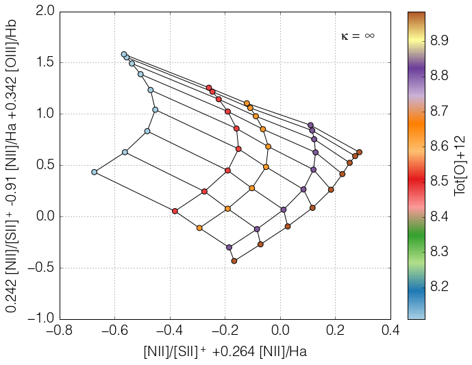

```python
bad_segments = pyqz.check_grid('[NII]/[SII]+;[NII]/Ha;[OIII]/Hb',
                coeffs = [[1.0,0.264,0.0],[0.242,-0.910,0.342]],
                show_plot=True,
                struct='sph',
                sampling=1)
```